# Deskriptive Regressionsanalyse

Grundlagen und Beispiel

Prof. Dr. Jörg Schoder

2023-05-20

# 1 Deskriptive Regressionsanalyse

- Etymologie: Ableitung vom lateinischen Verb “regredi” (“umkehren”, “zurückführen/-gehen”)
- Begriff findet sich in zahlreichen wissenschaftlichen Disziplinen: Psychologie, Geologie,. . .
- Einführung in die Statisik durch **Francis Galton (1822-1911)**:

> “the average regression of the offspring is a constant fraction of their respective mid-parental deviations” (Quelle: Wikipedia).

extreme Characteristika (hier: Körpergröße) der Eltern werden nicht vollständig an die Nachkommen weitergegeben. Vielmehr gibt es eine Regression (Tendenz der Rückkehr) zu einem mittleren Wert. Deskriptive vs. induktive/stochastische Regressionsanalyse.

## 1.1 Grundlagen

### 1.1.1 Korrelation vs. Kausalität

- Allein auf Basis einer Korrelationsanalyse können keine Aussagen über Kausalität (Ursache-Wirkungs-Zusammenhang) gemacht werden:
  - Möglichkeit der Diskrepanz von Formallogik und Sachlogik
  - Scheinkorrelation (third-variable problem): Die Korrelation kann durch einen dritten (nicht beobachteten) Faktor bestehen, der auf beide Variablen einwirkt
  - Richtung der Kausalität: Der Korrelationskoeffizient sagt nichts darüber aus, ob $X$ von $Y$ verursacht wird oder vice versa.

[interactive chart not shown]

- Bei statistischen Untersuchungen von Zusammenhängen zwischen Merkmalen ist besonders auf die sachliche Seite der Fragestellung zu achten (“theoriegeleitet statt datengetrieben”).

### 1.1.2 Korrelation vs. Regression

- Bei der Korrelation geht es um **Richtung und Stärke des Zusammenhangs** zwischen zwei Variablen. Es wird ein linearer Zusammenhang unterstellt.
- Bei der Regression geht es um die Vorhersage/Prognose von Werten einer Variable auf Basis einer anderen Variablen (bspw. Umsatzprognose auf Basis des Produktpreises).
  - hypothetisches Modell der Beziehung zwischen zwei oder mehr Variablen.
  - Abbildung des Zusammenhangs durch eine (möglichst einfache) Regressionsfunktion.
  - Einfachregression (bivariater Fall) vs. Mehrfachregression (Multiple Regression):
    - abhängige Variable: Regressand
    - unabhängige Variable(n): Regressor(en)
- Deskriptive Regressionsanalyse als Verallgemeinerung der Methode zur Berechnung einfacher Mittelwerte.

bedingter Mittelwert (Nutzung von Informationen aus der unabhängigen Variable)

### 1.1.3 Exakter vs. statistischer Zusammenhang

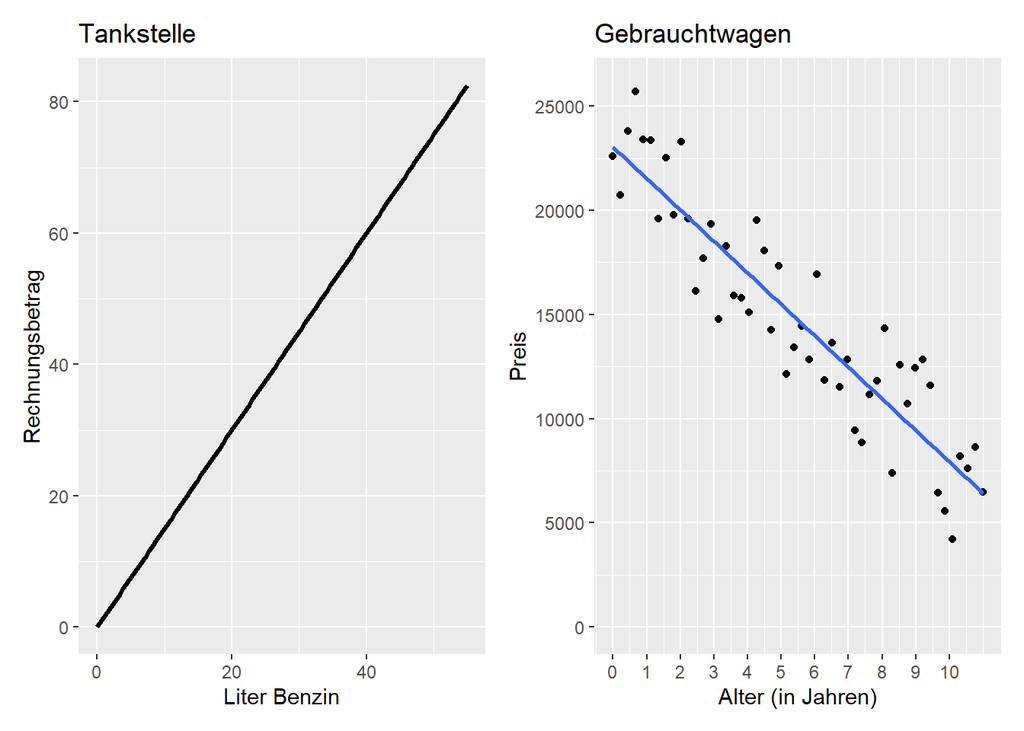

### 1.1.4 Lineare vs. nicht-lineare Zusammenhänge

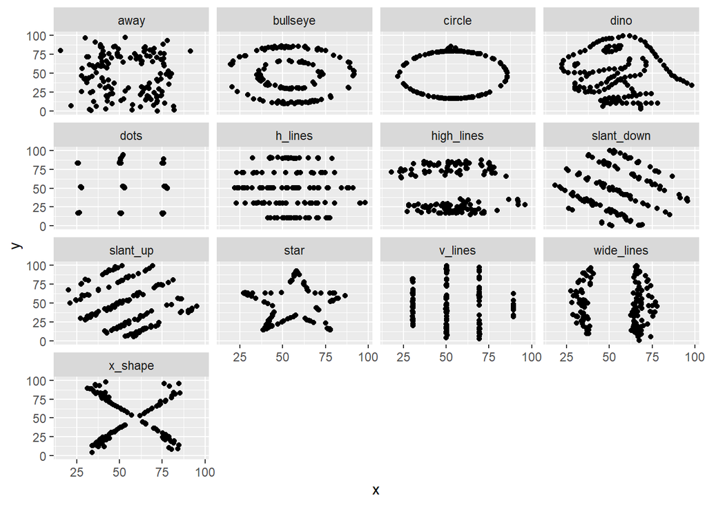

```r
datasauRus::datasaurus_dozen %>%
                    ggplot(aes(x, y)) +
                        geom_point() +
                        facet_wrap(~dataset)
```

### 1.1.5 Funktionstypen im bivariaten Fall

Im Folgenden sei $X$ der Regressor (unabhängige Variable) und $Y$ der Regressand (abhängige Variable) bzw. “Regression von Y auf X”: (y-x-Regression $\hat{y}=f(x)$).[^1]

- Gerade: $y=b_1+b_2x$
- Parabel: $y=b_1+b_2x+b_3x^2$
- Potenzfunktion: $y=b_1x^{b_2}$
- Exponentialfunktion: $y=b_1b_2^x$
- logistische Funktion: $y=\frac{k}{1+e^{b_1+b_2x}},~b_2<0.$
- …

Im Folgenden Betrachtung des einfachsten Falls: $y=b_1+b_2x$, mit:

- $b_1$: Interzept/Konstante
- $b_2$: Steigungskoeffizient

## 1.2 Regressionsfunktion (bivariater Fall)

### 1.2.1 Residuen

$$\begin{aligned}[t]
y_i&=\underbrace{b_1+b_2x_i}_{\mbox{systematische Komponente}}+\underbrace{e_i}_{\mbox{unsystematische Komponente}}\\
&=\underbrace{\hat{y}}_{\mbox{Regressionsfunktion}}+\underbrace{e_i}_{\mbox{Residuum}}
\end{aligned}$$

Die Differenzen zwischen den beobachteten Werten $y_i$ des metrisch messbaren Merkmals Y und den mittels Regressionsfunktion vorhergesagten Werten $\hat{y_i}$ heißen **Residuen** (von Residualgröße, engl. residuals) $e_i$ bezeichnet. Für das Residuum der Beobachtung $i$ gilt: $e_i = y_i - \hat{y}_i ~\mbox{für}~i = 1,\dots, n$.

### 1.2.2 Methode der kleinsten Quadrate

- Es gibt diverse Möglichkeiten, um eine Gerade durch eine Punktwolke im Streudiagramm zu legen.

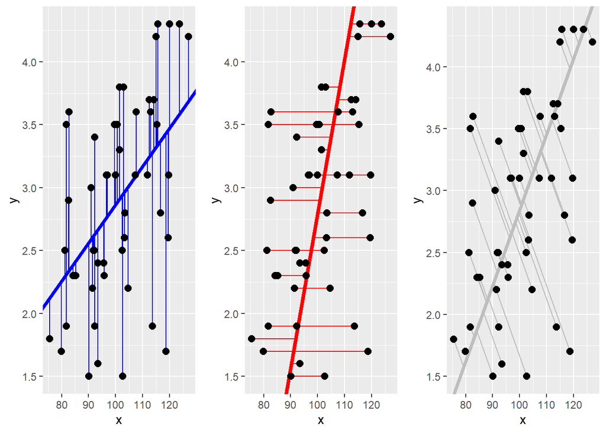

Figure 1.1: Alternative Distanzmaße

- Naheliegend: Gerade, welche einen möglichst großen (geringen) Anteil der systematischen (unsystematischen Komponente) mit sich bringt: Maximierung (Minimierung) der (durch die Regressionsfunktion $\hat{y}$) erklärten (nicht erklärten) Streuung der beobachteten $y$-Werte.
- Obs! Unsystematische Komponente entspricht dem Teil der Gesamtstreuung der y-Werte, der nicht durch die Regressionsfunktion ($\hat{y}$) erklärt ist; mithin: Residuen als nicht erklärte Streuung.
- Operationalisierung “`möglichst geringer Anteil nicht erklärter Streuung”’? Absolute Abweichung, Gewichtete Abweichungen (quadratisch, konstant)?
- Methode der kleinsten Quadrate (Ordinary Least Squares, OLS):

$$\begin{equation}
\min_{b_1,b_2}\sum_{i=1}^ne_i^2=\sum_{i=1}^n(y_i-\hat{y})^2=\sum_{i=1}^n(y_i-b_1-b_2x_i)^2
\tag{1.1}
\end{equation}$$

[interactive chart not shown]

Obs! Die Regressionsgerade ist diejenige Gerade, welche die Summe der quadrierten Vorhersagefehler (Residuen) minimiert.

### 1.2.3 Ermittlung der Parameter des Regressionsmodells

- Bedingungen erster Ordnung:

$$\begin{equation}
\frac{\partial\sum_ie_i^2}{\partial b_1}=-2\sum_i(y_i-b_1-b_2x_i)=-2\sum_i e_i\stackrel{!}{=}0
\tag{1.2}
\end{equation}$$

$$\begin{equation}
\frac{\partial\sum_ie_i^2}{\partial b_2}=-2\sum_i(y_i-b_1-b_2x_i)x_i=-2\sum_i x_ie_i\stackrel{!}{=}0
\tag{1.3}
\end{equation}$$

- Umstellung von Gleichung (1.2) liefert **Bestimmungsgleichung für $b_1$**:

$$\begin{equation}
\sum y_i=n b_1+b_2\sum x_i\implies b_1=\bar{y}-b_2\bar{x}
\tag{1.4}
\end{equation}$$
.

- Einsetzen von (1.4) in (1.3) liefert **Bestimmungsgleichung für $b_2$**:

$$\begin{equation*}
b_2=\frac{\sum_i(x_i-\bar{x})(y_i-\bar{y})}{\sum_i(x_i-\bar{x})^2} \iff b_2=\frac{\frac{1}{n}\sum_i(x_i-\bar{x})(y_i-\bar{y})}{\frac{1}{n}\sum_i(x_i-\bar{x})^2}
\end{equation*}$$

- Damit:

$$\begin{equation}
b_2=\frac{\mbox{COV}(y,x)}{\mbox{Var}(x)}
\tag{1.5}
\end{equation}$$

### 1.2.4 Exkurs: Multiple Regression

[figure not shown]

- Von der Geradengleichung zur Linearkombination:

$$y_i=b_{i1}x_{i1}+b_{i2}x_{i2}+b_{i3}x_{i3}+\dots+b_{ik}x_{ik}+e_i$$

- Matrizendarstellung:

$$\begin{pmatrix}
y_1 \\
y_2 \\
\vdots \\
y_i
\end{pmatrix}
=
\begin{pmatrix}
x_{1,1} & x_{1,2} & \cdots & x_{1,k} \\
x_{2,1} & x_{2,2} & \cdots & x_{2,k} \\
\vdots & \vdots & \ddots & \vdots \\
x_{i,1} & x_{i,2} & \cdots & x_{i,k}
\end{pmatrix}
\cdot
\begin{pmatrix}
b_1 \\
b_2 \\
\vdots \\
b_k
\end{pmatrix}
+
\begin{pmatrix}
e_1 \\
e_2 \\
\vdots \\
e_i
\end{pmatrix}$$

- Kompakte Matrizen-Schreibweise:

$$\textbf{y}=\textbf{X}\cdot b+e$$

Analog zur linearen Einfachregression sollen die quadrierten Residuen minimiert werden:

$$\begin{eqnarray}\min_\beta(e'e)&=&\min_\beta(y-X\beta)'(y-X\beta)\\
&=&\min_\beta[y'y-2\beta'X'y+\beta'X'X\beta]\,
\end{eqnarray}$$

- Bedingung erster Ordnung (FOC):

$$\frac{\partial(e'e)}{\partial b}=-2X'y+2X'X b\stackrel{!}{=}0$$

Damit folgt für die Koeffizienten:

$$b=(X'X)^{-1}X'y$$

### 1.2.5 Interpretation einer linearen KQ-Regressionsfunktion

- Ist $b_1$ im Verhältnis zu den beobachteten x-Werten klein, besteht zwischen $X$ und $Y$ ein annähernd proportionaler Zusammenhang
- Obs! Regression ohne Interzept ($b_1 = 0$) entspricht einer Ursprungsgerade Gefahr der Verzerrung (Bias)!
- Die Regressionskoeffizienten geben keine Auskunft über Ausgeprägtheit/Stärke des (linearen) Zusammenhangs, sondern nur die Tendenz! Stärke des Zusammenhangs: Korrelationsanalyse.
- Obs! Für inferenzstatistische Zwecke (vgl. Stichproben und Inferenz) müssen diverse Annahmen getroffen werden (Ökonometrie).

## 1.3 Eigenschaften und Einordnung von Regressionsparametern

### 1.3.1 Eigenschaften der KQ-Residuen

- Aus Gleichung (1.2) folgt: $\sum_i(y_i-b_1-b_2x_i)=\sum_i(y_i-\hat{y}_i)=\sum_ie_i=0.$ Für eine lineare KQ-Regressionsfunktion ist die **Summe der Residuen gleich Null**.
- Damit haben lineare KQ-Regressionsfunktionen (mit Interzept) stets ein **arithemetisches Mittel der Residuen von Null** ($\hat{e}=0$).
- Damit gilt für die Varianz der Residuen: $s_e^2=\frac{1}{n}\sum_ie_i^2$. Gemäß Gleichung(1.1) entspricht dies aber gerade der Zielfunktion der KQ-Methode: $\min_{b_1,b_2}\sum_{i=1}^ne_i^2$. Das Kriterium der Kleinsten KQ entspricht bei linearen Regressionsfunktionen (mit Interzept) der **Minimierung der Varianz der Residuen**.

Obs! Diese Ergebnisse lassen sich noch verallgemeinern. Sie gelten für alle Regressionsfunktionen der Form $f(x)=b_1+f^\ast(x)$, wobei $f^\ast(x)$ keine additive Konstante mehr hat.

### 1.3.2 Regressionskoeffizient vs. Korrelationskoeffizient

- Korrelationskoeffizient nach Bravais-Pearson:
  $$\begin{equation*}
  r_{XY}=\frac{s_{XY}}{s_X\cdot s_Y}
  \end{equation*}$$
- Auflösen nach $s_{XY}=r_{XY}\cdot s_X\cdot s_Y$ und Einsetzen in (1.5):
  $$\begin{equation*}
  b_2=\frac{r_{XY}\cdot s_X\cdot s_Y}{s_X^2}=r_{XY}\frac{s_Y}{s_X}
  \end{equation*}$$
- Steigung ist somit direkt proportional zur Korrelation. Die Steigung ist positiv (negativ), wenn die Korrelation positiv (negativ) ist.
- Obs! Wert der Steigung abhängig von den Standardabweichungen von Regressand und Regressor: Steigung ($b_2$) kein standardisiertes Maß für den Einfluss von X auf Y!

### 1.3.3 Goodness-of-Fit und Bestimmtheitsmaß

https://www.uibk.ac.at/econometrics/einf/kap02_ols.pdf

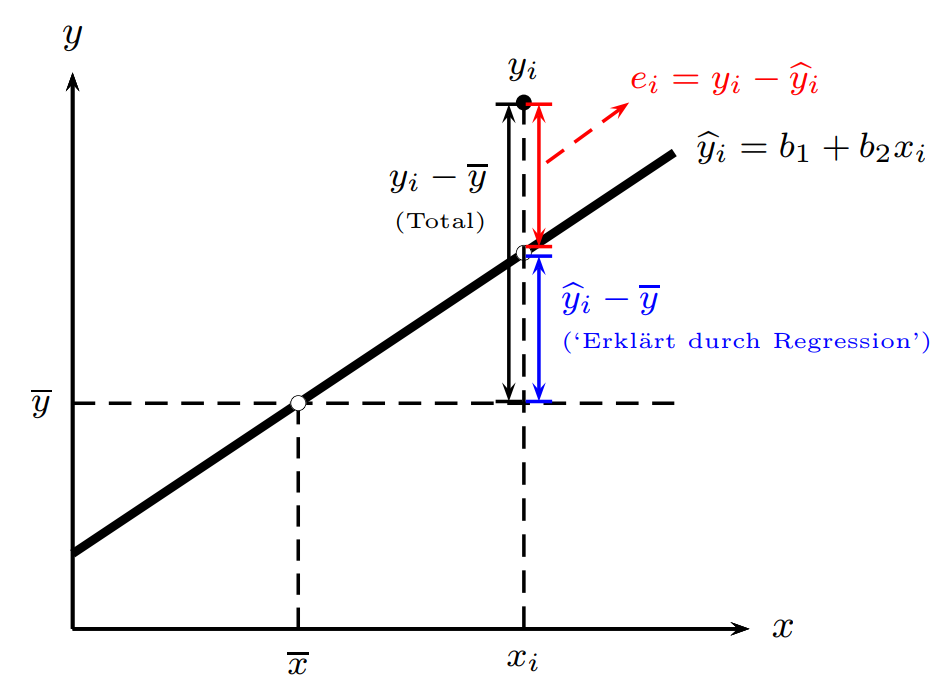

Figure 1.2: Varianzzerlegung; Quelle: Stocker (2023).

- Abweichung einer einzelnen Beobachtung vom Mittelwert $\bar{y}$:

$$\begin{equation}
y_i-\bar{y}=(\hat{y}_i-\bar{y})+(y_i-\hat{y}_i)
\tag{1.6}
\end{equation}$$

- Ermittlung der Gesamtstreuung von $y$ um den Mittelwert $\bar{y}$ durch quadrieren von Gleichung (1.6) und aufsummieren über alle Beobachtungen sowie diverse Umformungen:

$$\begin{equation*}
\sum_i(y_i-\bar{y})^2=\sum_i(\hat{y}_i-\bar{y})^2+\sum_i(y_i-\hat{y})^2
\end{equation*}$$
bzw.
$$\begin{equation*}
\underbrace{\sum_i(y_i-\bar{y})^2}_{\mbox{TSS}}=\underbrace{\sum_i(\hat{y}_i-\bar{y})^2}_{\mbox{ESS}}+\underbrace{\sum_i e_i^2}_{\mbox{SSR}}
\end{equation*}$$

- Die Gesamtstreuung (“Total Sum Squared”, TSS) ergibt sich als Summe aus erklärter Streuung (“Explained Sum Squared”, ESS) und nicht erklärter Streuung (“Sum of Squared Residuals”, SSR).

Das Bestimmtheitsmaß $R^2$ (engl. R squared) ist definiert als Anteil der durch die Regressionsgerade erklärten Streuung (ESS) an der gesamten Streuung (TSS):
$$\begin{equation*}
R^2 =\frac{\mbox{ESS}}{\mbox{TSS}}=\frac{\mbox{TSS}-\mbox{SSR}}{TSS}=1-\frac{\mbox{SSR}}{TSS}=1-\frac{\sum_i e_i^2}{\sum_i(y_i-\bar{y})^2}
\end{equation*}$$

Obs! Für Regressionsgleichungen mit Interzept gilt: $0\leq R^2\leq 1$.

[figure not shown]

- Das Bestimmtheitsmaß (auch Determinationskoeffizient) enstspricht der quadrierten Korrelation zwischen beobachtetem und vorhergesagtem Wert:

$$\begin{equation*}
R^2 = r_{y,\hat{y}}^2
\end{equation*}$$

- Spezialfall lineare Einfachregression (eine unabhängige Variable)
  - Obs! Im Fall der linearen **Einfach**regression sind die vorhergesagten Werte ($\hat{y}$) eine lineare Transformation des Regressors ($\hat{y}=b_1+b_2x$)
  - Außerdem: Die Korrelation $r$ ist invariant gegenüber linearen Transformationen der Variablen
  - Mithin kann **im Fall der einfachen linearen Regression** das Bestimmtheitsmaß auch via Quadrieren der Korrelation zwischen Regressor und Regressand bestimmt werden:

$$R^2=r_{x,y}^2$$